# NU-IT Research Computing Services: Regression Models with R - Day 1

By Diego Gomez-Zara

In this workshop, we will learn about the R modeling ecosystem to run linear and logistic regression models. We will also cover model diagnostics, variable selection, and generalized linear models (GLM). Our goals are to learn about:

1. Visualizing, summarizing, and standarizing data before modeling
2. Using linear regressions for continuous outcomes
3. Using logistic regressions for binary outcomes
4. Running diagnostics and goodness of fit
5. Running variable selection and model building.

This workshop aims to teach you how to use R for building linear regressions. It does not intent to provide mathematical explanations or interpretations of the results, since it is not a statistics workshop. However, we will discuss how models are build and diagnosed, and how the model results are organized. If you have specific questions about choosing, evaluating, and interpreting statisticals models or tests, we encourage you to consult with a statistic experts. [The Biostatistics Collaboration Center](https://www.feinberg.northwestern.edu/sites/bcc/) is an excellent resource for researchers affiliated with the Feinberg School of Medicine.Other researchers may request a consult for statistics questions and NU-IT Research Computing Services will evaluate their ability to help on a request by request basis.

We will load the library `dplyr` for data cleaning and transforming. The second library is `Hmisc`, we will use it for correlation analysis. We will use the third library to plot data’s correlations.

```r
library(dplyr)
library(Hmisc)
library(PerformanceAnalytics)
```

We will clean the environment and set a random seed, so we can have all the same results in our environments.

```r
rm(list = ls())
set.seed(40)
```

## 1. Import Dataset

This is the “Medical Cost Personal Datasets” dataset and it was downloaded from [Kaggle](https://www.kaggle.com/mirichoi0218/insurance). The motivation is to predic the insurance costs based on individuals’ demographics and health conditions. The file has the following columns:

- **age**: age of primary beneficiary
- **gender**: insurance contractor gender. Two values: female, male
- **bmi**: Body mass index, providing an understanding of body, weights that are relatively high or low relative to height, objective index of body weight (kg / m ^ 2) using the ratio of height to weight, ideally 18.5 to 24.9
- **children**: Number of children covered by health insurance / Number of dependents
- **smoker**: Smoking
- **region**: the beneficiary’s residential area in the US, northeast, southeast, southwest, northwest.
- **charges**: Individual medical costs billed by health insurance

```r
data <- read.csv("insurance.csv")
```

Let’s start examining the dataset to understand the attributes, their format and scales.

```r
data
```

| age | gender | bmi | children | smoker | region | charges |
| --- | --- | --- | --- | --- | --- | --- |
| 19 | female | 27.900 | 0 | yes | southwest | 16884.924 |
| 18 | male | 33.770 | 1 | no | southeast | 1725.552 |
| 28 | male | 33.000 | 3 | no | southeast | 4449.462 |
| 33 | male | 22.705 | 0 | no | northwest | 21984.471 |
| 32 | male | 28.880 | 0 | no | northwest | 3866.855 |
| 31 | female | 25.740 | 0 | no | southeast | 3756.622 |
| 46 | female | 33.440 | 1 | no | southeast | 8240.590 |
| 37 | female | 27.740 | 3 | no | northwest | 7281.506 |
| 37 | male | 29.830 | 2 | no | northeast | 6406.411 |
| 60 | female | 25.840 | 0 | no | northwest | 28923.137 |

[output cut: 1328 more lines]

We can observe that some columns are numeric (`age, bmi, children, charges`), and others are categorical (`gender, smoker, region`). R linear regressions support categorical variables, but we need to transform the string variables first to vectors.

```r
data$gender <- as.factor(data$gender)
```

When we have categorical variables, the regression model will compare all the results with respect to a specific category. That category is called *reference level*. By default, R chooses the reference level *alphabetically*, so in the case of `gender`, `female` will be the reference level. Given that it’s a binary variable, it will compare `male` individuals’ charges with respect to `female` individuals. We can re-order and set `male` as the reference by running the command `relevel` and using the paramater `ref`.

```r
data$gender <- relevel(data$gender, ref = "male")
```

### Exercise 1

Transform the variables `smoker` and `region` to factors. For the `smoker` variable, set `No` as the reference level.

```r
data$smoker <- as.factor(data$smoker)
data$smoker <- relevel(data$smoker, ref = "no")
data$region <- as.factor(data$region)
```

## 2. Analyze the dataset

We start analyzing the dataset that is numeric.

```r
data_numeric <- data %>% dplyr::select(where(is.numeric))
data_numeric
```

| age | bmi | children | charges |
| --- | --- | --- | --- |
| 19 | 27.900 | 0 | 16884.924 |
| 18 | 33.770 | 1 | 1725.552 |
| 28 | 33.000 | 3 | 4449.462 |
| 33 | 22.705 | 0 | 21984.471 |
| 32 | 28.880 | 0 | 3866.855 |
| 31 | 25.740 | 0 | 3756.622 |
| 46 | 33.440 | 1 | 8240.590 |
| 37 | 27.740 | 3 | 7281.506 |
| 37 | 29.830 | 2 | 6406.411 |
| 60 | 25.840 | 0 | 28923.137 |

[output cut: 1328 more lines]

We check the correlations of these numeric variables.

```r
corr <- cor(data_numeric, use = "complete.obs")
corr
```

```
##                age       bmi   children    charges
## age      1.0000000 0.1092719 0.04246900 0.29900819
## bmi      0.1092719 1.0000000 0.01275890 0.19834097
## children 0.0424690 0.0127589 1.00000000 0.06799823
## charges  0.2990082 0.1983410 0.06799823 1.00000000
```

The function rcorr() [in Hmisc package] can be used to compute the significance levels for pearson and spearman correlations. It returns both the correlation coefficients and the p-value of the correlation for all possible pairs of columns in the data table.

```r
res <- rcorr(as.matrix(data_numeric))
res
```

```
##           age  bmi children charges
## age      1.00 0.11     0.04    0.30
## bmi      0.11 1.00     0.01    0.20
## children 0.04 0.01     1.00    0.07
## charges  0.30 0.20     0.07    1.00
##
## n= 1338
##
##
## P
##          age    bmi    children charges
## age             0.0000 0.1205   0.0000
## bmi      0.0000        0.6410   0.0000
## children 0.1205 0.6410          0.0129
## charges  0.0000 0.0000 0.0129
```

The output of the function `rcorr()` is a list containing the following elements: * `r` : the correlation matrix * `n` : the matrix of the number of observations used in analyzing each pair of variables * `P` : the p-values corresponding to the significance levels of correlations.

If you want to extract the p-values or the correlation coefficients from the output, use this command:

```r
# Extract the correlation coefficients
res$r
```

```
##                age       bmi   children    charges
## age      1.0000000 0.1092719 0.04246900 0.29900819
## bmi      0.1092719 1.0000000 0.01275890 0.19834097
## children 0.0424690 0.0127589 1.00000000 0.06799823
## charges  0.2990082 0.1983410 0.06799823 1.00000000
```

```r
# Extract p-values
res$P
```

```
##                   age          bmi   children      charges
## age                NA 6.194289e-05 0.12049276 0.000000e+00
## bmi      6.194289e-05           NA 0.64101040 2.460254e-13
## children 1.204928e-01 6.410104e-01         NA 1.285213e-02
## charges  0.000000e+00 2.460254e-13 0.01285213           NA
```

Using the package, we can plot the histograms and the relationships among variables using one command

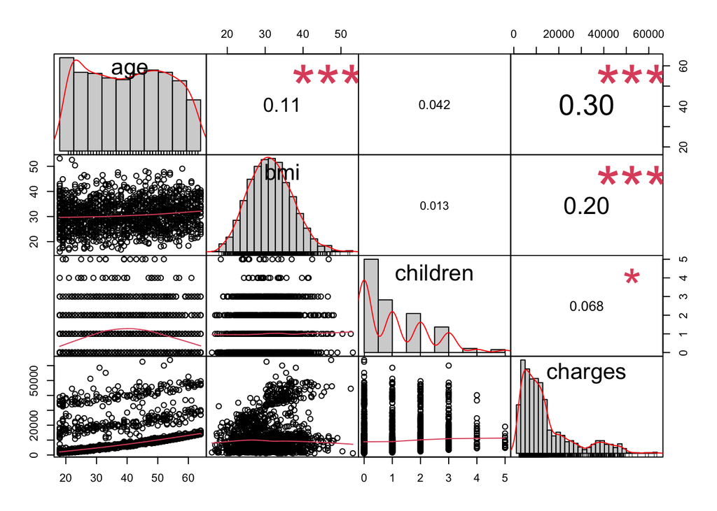

```r
chart.Correlation(data_numeric, histogram=TRUE, pch=19)
```

## 3. Scaling the dataset

As we saw, the columns have different scales, minimum, and maximum values. It is a good practice to scale the columns before running a model.

Standardization of datasets is a common requirement for regression models. The goal is to transform each variable to **zero mean and unit variance**. This process **transforms the data to center it by removing the mean value of each feature, then scales it by dividing non-constant features by their standard deviation**. However, this transformation does not change the distribution of the data.

[figure not shown]

where *Z* is the standard score, *x* is the observed value, *u* is the mean of the sample, and is *s* the standard deviation of the sample.

The function `scale`centers and scales the columns of a numeric dataframe.

```r
data <- data %>% mutate_if(is.numeric, scale)
```

We now see how the data is distributed, their means, and standard deviations.

```r
summary(data)
```

```
##         age.V1           gender          bmi.V1            children.V1
##  Min.   :-1.5094011   male  :676   Min.   :-2.411110   Min.   :-0.908274
##  1st Qu.:-0.8688299   female:662   1st Qu.:-0.716139   1st Qu.:-0.908274
##  Median :-0.0147349                Median :-0.043193   Median :-0.078738
##  Mean   : 0.0000000                Mean   : 0.000000   Mean   : 0.000000
##  3rd Qu.: 0.8393600                3rd Qu.: 0.660910   3rd Qu.: 0.750799
##  Max.   : 1.7646295                Max.   : 3.684145   Max.   : 3.239407
##  smoker           region        charges.V1
##  no :1064   northeast:324   Min.   :-1.003182
##  yes: 274   northwest:325   1st Qu.:-0.704387
##             southeast:364   Median :-0.321089
##             southwest:325   Mean   : 0.000000
##                             3rd Qu.: 0.278240
##                             Max.   : 4.170104
```

We check that the standard deviations are equal to the unit (1).

```r
apply(data[sapply(data, is.numeric)],2,sd)
```

```
##      age      bmi children  charges
##        1        1        1        1
```

## 4. Build a linear model

Once the data have been inspected, cleaned, and standarized, we can start estimating models. The simplest models (but those with the most assumptions) are those for continuous and unbounded outcomes. We use a linear regression model estimated using Ordinary Least Lquares (OLS), which in R can be fit with the `lm()` (linear model) function.

To fit a model in R, we first have to convert our theoretical model into a `formula` — a symbolic representation of the model in R syntax. We then can use `lm()` to fit this model.

```r
model0 <- lm(charges ~ age, data)
```

We can inspect the methods available for an object `lm`.

```r
methods(class = class(model0))
```

```
##  [1] add1           alias          anova          attrassign     case.names
##  [6] coerce         concordance    confint        cooks.distance deviance
## [11] dfbeta         dfbetas        drop1          dummy.coef     effects
## [16] extractAIC     family         formula        fortify        hatvalues
## [21] influence      initialize     kappa          labels         logLik
## [26] model.frame    model.matrix   nobs           plot           predict
## [31] print          proj           qr             residuals      rstandard
## [36] rstudent       show           simulate       slotsFromS3    summary
## [41] variable.names vcov
## see '?methods' for accessing help and source code
```

We can get more information by passing the fitted model object to the `summary()` function, which provides standard errors, test statistics, and p-values for individual coefficients, as well as goodness-of-fit measures for the overall model.

```r
summary(model0)
```

```
##
## Call:
## lm(formula = charges ~ age, data = data)
##
## Residuals:
##     Min      1Q  Median      3Q     Max
## -0.6655 -0.5509 -0.4905  0.4492  3.9496
##
## Coefficients:
##               Estimate Std. Error t value Pr(>|t|)
## (Intercept) -1.931e-17  2.610e-02    0.00        1
## age          2.990e-01  2.611e-02   11.45   <2e-16 ***
## ---
## Signif. codes:  0 '***' 0.001 '**' 0.01 '*' 0.05 '.' 0.1 ' ' 1
##
## Residual standard error: 0.9546 on 1336 degrees of freedom
## Multiple R-squared:  0.08941,    Adjusted R-squared:  0.08872
## F-statistic: 131.2 on 1 and 1336 DF,  p-value: < 2.2e-16
```

Residuals are useful for checking the goodness of fit and diagnose model violations. We will check more about R^2 and residuals this week.

We can use the `confint()` method to get interval estimates for the coefficients:

```r
confint(model0)
```

```
##                  2.5 %    97.5 %
## (Intercept) -0.0511963 0.0511963
## age          0.2477928 0.3502236
```

And we can use the `anova()` method to get an ANOVA-style table of the model

```r
anova(model0)
```

|  | Df | Sum Sq | Mean Sq | F value | Pr(>F) |
| --- | --- | --- | --- | --- | --- |
| age | 1 | 119.5357 | 119.5356879 | 131.174 | 4.886693e-29 |
| Residuals | 1336 | 1217.4643 | 0.9112757 | NA | NA |

And we can predict values by using the `predict` function. We take the `data`’s first observation and check the real value with the predicted.

```r
print(data$charges[1])
```

```
## [1] 0.2984722
```

```r
predict(model0, data[1,], se.fit = TRUE)
```

```
## $fit
##          1
## -0.4300415
##
## $se.fit
## [1] 0.04572661
##
## $df
## [1] 1336
##
## $residual.scale
## [1] 0.9546076
```

### Adding more variables

We can continue adding more variables to the model and check whether the new model is significantly better than `model0`.

```r
model1 <- lm(charges ~ age + bmi, data)
summary(model1)
```

```
##
## Call:
## lm(formula = charges ~ age + bmi, data = data)
##
## Residuals:
##     Min      1Q  Median      3Q     Max
## -1.1938 -0.5817 -0.4241  0.5955  3.9655
##
## Coefficients:
##              Estimate Std. Error t value Pr(>|t|)
## (Intercept) 1.326e-17  2.571e-02   0.000        1
## age         2.807e-01  2.587e-02  10.850  < 2e-16 ***
## bmi         1.677e-01  2.587e-02   6.481 1.28e-10 ***
## ---
## Signif. codes:  0 '***' 0.001 '**' 0.01 '*' 0.05 '.' 0.1 ' ' 1
##
## Residual standard error: 0.9403 on 1335 degrees of freedom
## Multiple R-squared:  0.1172, Adjusted R-squared:  0.1159
## F-statistic:  88.6 on 2 and 1335 DF,  p-value: < 2.2e-16
```

Compare the models using an F-test with the `anova()` function

```r
anova(model0, model1)
```

|  | Res.Df | RSS | Df | Sum of Sq | F | Pr(>F) |
| --- | --- | --- | --- | --- | --- | --- |
| 1 | 1336 | 1217.464 | NA | NA | NA | NA |
| 2 | 1335 | 1180.326 | 1 | 37.1385 | 42.00526 | 1.277594e-10 |

### Exercise 2

Create four models by adding sequentially the following attributes: `children, gender, smoker, region`. * `model2`: `model1` and `children`. * `model3`: `model2` and `gender`. * `model4`: `model3` and `smoker`. * `model5`: `model4` and `region`.

For each model, run the functions `summary`,`confint`, and `anova`.

```r
model2 <- lm(charges ~ age + bmi + children, data)
summary(model2)
```

```
##
## Call:
## lm(formula = charges ~ age + bmi + children, data = data)
##
## Residuals:
##     Min      1Q  Median      3Q     Max
## -1.1465 -0.5775 -0.4205  0.5884  4.0155
##
## Coefficients:
##              Estimate Std. Error t value Pr(>|t|)
## (Intercept) 2.732e-17  2.567e-02   0.000   1.0000
## age         2.784e-01  2.586e-02  10.767  < 2e-16 ***
## bmi         1.672e-01  2.584e-02   6.472 1.35e-10 ***
## children    5.404e-02  2.571e-02   2.102   0.0357 *
## ---
## Signif. codes:  0 '***' 0.001 '**' 0.01 '*' 0.05 '.' 0.1 ' ' 1
##
## Residual standard error: 0.9391 on 1334 degrees of freedom
## Multiple R-squared:  0.1201, Adjusted R-squared:  0.1181
## F-statistic: 60.69 on 3 and 1334 DF,  p-value: < 2.2e-16
```

```r
model3 <- lm(charges ~ age + bmi + children + gender, data)
summary(model3)
```

```
##
## Call:
## lm(formula = charges ~ age + bmi + children + gender, data = data)
##
## Residuals:
##     Min      1Q  Median      3Q     Max
## -1.1893 -0.5846 -0.4131  0.5494  3.9598
##
## Coefficients:
##              Estimate Std. Error t value Pr(>|t|)
## (Intercept)   0.05400    0.03610   1.496   0.1349
## age           0.27991    0.02583  10.835  < 2e-16 ***
## bmi           0.16455    0.02584   6.369 2.61e-10 ***
## children      0.05307    0.02568   2.067   0.0389 *
## genderfemale -0.10914    0.05136  -2.125   0.0338 *
## ---
## Signif. codes:  0 '***' 0.001 '**' 0.01 '*' 0.05 '.' 0.1 ' ' 1
##
## Residual standard error: 0.9379 on 1333 degrees of freedom
## Multiple R-squared:  0.1231, Adjusted R-squared:  0.1204
## F-statistic: 46.77 on 4 and 1333 DF,  p-value: < 2.2e-16
```

```r
model4 <- lm(charges ~ age + bmi + children + gender + smoker, data)
summary(model4)
```

```
##
## Call:
## lm(formula = charges ~ age + bmi + children + gender + smoker,
##     data = data)
##
## Residuals:
##     Min      1Q  Median      3Q     Max
## -0.9775 -0.2409 -0.0821  0.1136  2.4414
##
## Coefficients:
##              Estimate Std. Error t value Pr(>|t|)
## (Intercept)  -0.40812    0.02089 -19.540  < 2e-16 ***
## age           0.29902    0.01381  21.651  < 2e-16 ***
## bmi           0.16233    0.01381  11.757  < 2e-16 ***
## children      0.04723    0.01372   3.441 0.000597 ***
## genderfemale  0.01062    0.02753   0.386 0.699641
## smokeryes     1.96725    0.03406  57.750  < 2e-16 ***
## ---
## Signif. codes:  0 '***' 0.001 '**' 0.01 '*' 0.05 '.' 0.1 ' ' 1
##
## Residual standard error: 0.5012 on 1332 degrees of freedom
## Multiple R-squared:  0.7497, Adjusted R-squared:  0.7488
## F-statistic:   798 on 5 and 1332 DF,  p-value: < 2.2e-16
```

```r
model5 <- lm(charges ~ age + bmi + children + gender + smoker + region, data)
summary(model5)
```

```
##
## Call:
## lm(formula = charges ~ age + bmi + children + gender + smoker +
##     region, data = data)
##
## Residuals:
##     Min      1Q  Median      3Q     Max
## -0.9335 -0.2352 -0.0811  0.1151  2.4767
##
## Coefficients:
##                 Estimate Std. Error t value Pr(>|t|)
## (Intercept)     -0.35906    0.03212 -11.180  < 2e-16 ***
## age              0.29800    0.01380  21.587  < 2e-16 ***
## bmi              0.17081    0.01440  11.860  < 2e-16 ***
## children         0.04733    0.01372   3.451 0.000577 ***
## genderfemale     0.01084    0.02749   0.394 0.693348
## smokeryes        1.96932    0.03412  57.723  < 2e-16 ***
## regionnorthwest -0.02915    0.03933  -0.741 0.458769
## regionsoutheast -0.08547    0.03953  -2.162 0.030782 *
## regionsouthwest -0.07928    0.03947  -2.009 0.044765 *
## ---
## Signif. codes:  0 '***' 0.001 '**' 0.01 '*' 0.05 '.' 0.1 ' ' 1
##
## Residual standard error: 0.5006 on 1329 degrees of freedom
## Multiple R-squared:  0.7509, Adjusted R-squared:  0.7494
## F-statistic: 500.8 on 8 and 1329 DF,  p-value: < 2.2e-16
```

Finally, compare all the models

```r
anova(model0, model1, model2, model3, model4, model5)
```

|  | Res.Df | RSS | Df | Sum of Sq | F | Pr(>F) |
| --- | --- | --- | --- | --- | --- | --- |
| 1 | 1336 | 1217.4643 | NA | NA | NA | NA |
| 2 | 1335 | 1180.3258 | 1 | 37.138499 | 148.206388 | 2.114426e-32 |
| 3 | 1334 | 1176.4287 | 1 | 3.897101 | 15.551926 | 8.445622e-05 |
| 4 | 1333 | 1172.4571 | 1 | 3.971654 | 15.849440 | 7.229729e-05 |
| 5 | 1332 | 334.6210 | 1 | 837.836054 | 3343.502231 | 0.000000e+00 |
| 6 | 1329 | 333.0293 | 3 | 1.591732 | 2.117343 | 9.622108e-02 |

### References and resources

- [Institute for Quantitative Social Science - Data Science Workshops](https://iqss.github.io/dss-workshops/Rmodels.html)